# RNA-seq Data Analysis Workflow

by Alberto Berral, Natalia Alonso & Javier De Las Rivas (CiC-IBMCC, CSIC/USAL)

Updated 01.Jun.2024

### Bulk RNA-seq analyses: based on “fastq2counts” pipeline (from raw fastq data to gene expression calculation)

## Abstract:

This pipeline aims to provide a quick and easy way to prepare an RNA-seq raw-counts matrix from **fastq** files together with the related experiment information, being each part of the process explained step by step. In addition, we will do all the steps with an example: a sample set of 10 samples from **GSE162104**, that includes RNA-seq of primary colorectal cancer cell lines (60 samples), done with Illumina HiSeq 4000 (Homo sapiens): <**https://www.ncbi.nlm.nih.gov/geo/query/acc.cgi?acc=GSE162104**>

## Introduction:

When working with differential expression statistical methods such as DESeq2, Limma voom, edgeR, baySeq, etc., it is necessary to start from non-normalized data to perform the corresponding analysis because these algorithms already have inside methods of normalization and data scaling. Usually, the data offered in different repositories, such as NCBI, is normalized. However, it is possible to download the RNA-seq data of each sample in **fastq** format individually. Thus below are the necessary steps to arrive at the final **counts matrix**.

## Methods & Packages Required:

- Sra-toolkit v(2.10.7+dfsg-1)
- Fastqc v(0.11.9)
- Trimmomatic v(0.39)
- Salmon v(1.3.0)
- R & RStudio v(4.3.1) % v(2023.09.1+494)

## Data download:

There are different repositories where you can find datasets or projects to analyze. In this pipeline, we will use NCBI ([**https://www.ncbi.nlm.nih.gov/geo/browse/?view=series**](https://www.ncbi.nlm.nih.gov/geo/browse/?view=series)). Once you have chosen the project, you have to locate the ‘RUN code’ of each of the samples we want to download, these codes can be accessed using the tool SRA RUN SELECTOR TOOL. In this example we will use **GSE162104**.

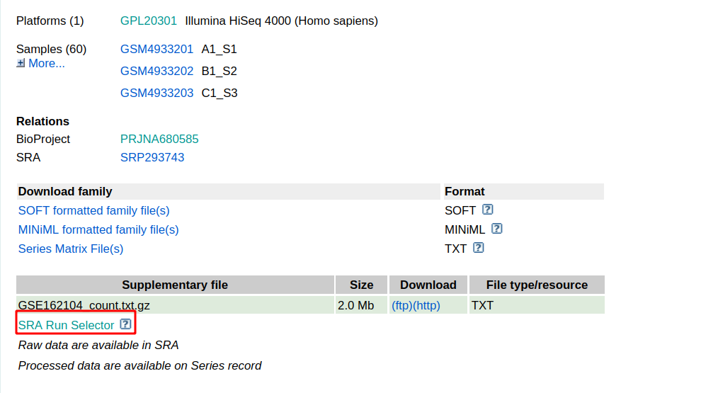

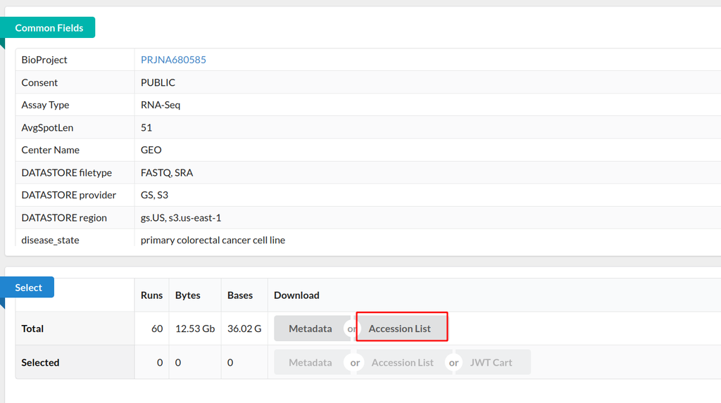

Once the desired samples have been selected, we will download the ‘**Accession List**’ to indicate to the algorithm the files you want to work with. We will download these 10 files: SRR13127892, SRR13127893, SRR13127894, SRR13127895, SRR13127896, SRR13127898, SRR13127899, SRR13127900, SRR13127901, SRR13127930

It is important to check if the samples of the chosen project are **single-end** or **paired-end** RNA-Seq. We can do this by checking the SRA information in the Library Layout section.

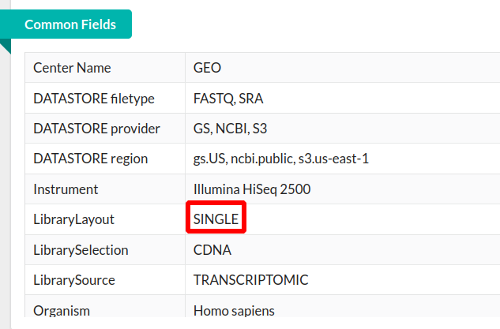

As we can see, in this case we have a single layout. So we will use the single type bash scripts.

## Terminal (UBUNTU or other LINUX Terminal)

### Download data:

Note: Before starting with the download script, it is necessary to create a directory where we will store all of the files (the bash scripts, samples, etc.). The **Accession List** mentioned above should also be saved in this directory. The data download function to save as **download_data.sh**.

To run this script, a terminal should be opened from the directory mentioned above and type the following command:

**bash download_data.sh SRR_Acc_List.txt**

After running the script and if everything went smoothly we should have something like this:

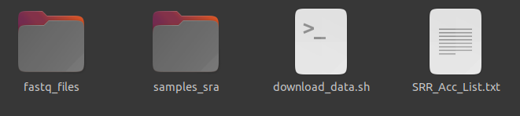

**: If openssl certificate error update sra toolkit.

**Inside the** samples_sra folder** are the .sra files we have downloaded. Inside the **fastq_files folder** are the same files but converted to fastq file format, which is the one we are going to use.

### Quality Check:

Once we have the **fastq** files, it is necessary to check their quality. The quality of each of the samples can be analyzed using the **fastqc** tool. Additionally, with the **trimmomatic** tool, we can trim those that do not meet the quality requirements. The bash script with the quality control functions is **quality_control_####.sh**:

To run this script a terminal should be opened from the directory mentioned above and type the following command depending on the type of data we have (single end or paired end):

**bash quality_control_single-end.sh SRR_Acc_List.txt**

After running the script we should have a new folder, **Quality_html**:

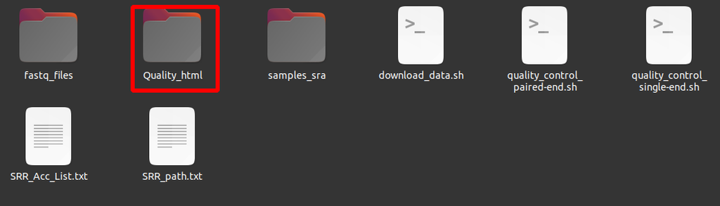

Depending on which experiment we are analyzing, it will be necessary to look at some parameters or others. For example, if the objective is to analyze the differential expression in samples referring to a type of cancer, the sections ‘Per base sequence quality’ and ‘Per sequence quality scores’ would be significant, while others like’ Sequence Duplication Levels’ would not have as much relevance.

[figure not shown]

If we have a lot of samples, we could run the script **fastqc_eval.py** using Python3:

**python3 fastqc_eval.py**

[figure not shown]

Once we have verified the quality of the samples, if all are valid, we would proceed with the alignment. On the contrary, it would be necessary to trim those bad-quality samples. You need to create a .txt with the names of the samples to be trimmed separated in the same way as in the **Accession List file**, the bash script with the functions for trimming the samples to be saved as **trimmomatic_single-end.sh**.

You can find the number of bp in the fastqc reports generated in the previous section, **‘Sequence Length Distribution’**, where the number of bp is the value on the x-axis with the highest value on the y-axis. In this example, the argument for introducing in MINLEN would be MINLEN: 26 since (51/2) + 1 = 26.

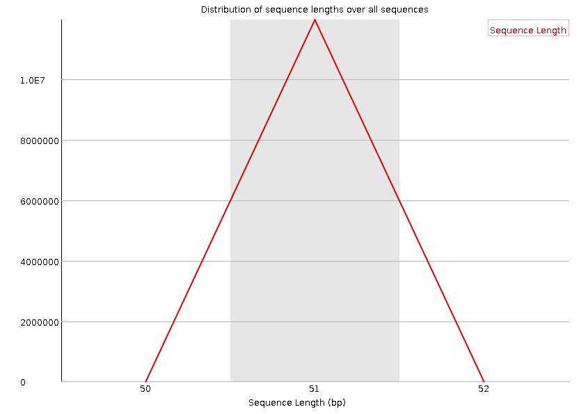

It is necessary to have previously the **list of illumina adapters**: open a txt file and save it in the directory such as Illumina_Adapters_SE.fa:

```
>TruSeq2_SE
AGATCGGAAGAGCTCGTATGCCGTCTTCTGCTTG
>TruSeq2_PE_f
AGATCGGAAGAGCGTCGTGTAGGGAAAGAGTGT
>TruSeq2_PE_r
AGATCGGAAGAGCGGTTCAGCAGGAATGCCGAG
>TruSeq3_IndexedAdapter
AGATCGGAAGAGCACACGTCTGAACTCCAGTCAC
>TruSeq3_UniversalAdapter
AGATCGGAAGAGCGTCGTGTAGGGAAAGAGTGTA
```

To run this script a terminal should be opened from the directory mentioned above and type the following command:

**bash trimmomatic_single-end.sh SRR_Acc_List_totrim.txt**

In case we wanted all SRR files to be trimmed we could use the SRR_Acc_List.txt file.

We can run again the quality control commando to check that the trimming is good. We need to run:

**bash quality_control_single-end.sh SRR_Acc_List.txt** and then **python3 fastqc_eval.py**

### Alignment and quantification:

To carry out this process, the **Salmon** tool will be used. The first step is to create a reference index. The bash file we run is:

**bash salmon_index.sh**.

- In case of error, curl might need to be installed.

Inside the **gencode** folder is the gencode.vXX.transcripts.fa.gz file, that can be also downloaded from https://www.gencodegenes.org/human/ for another version. Once the index is generated, we proceed to the make the alignment with the script **salmon_alignment.sh**. Open a terminal in the working directory and run:

**bash salmon_alignment.sh SRR_Acc_List.txt**.

After we run everything our folder should looks like this:

[figure not shown]

# R & Rstudio

### Reading data in R:

INSTALL the following PACKAGES using ‘pacman’: **tximeta**, **SummarizedExperiment**, **tidyverse**, **ggplot2** … or … better INSTALL the PACKAGES from Bioconductor (installing all the OR from R-cran one by one:

```r
# Basic R-project layout
ifelse(file.exists('data/'), '', dir.create('data/'))
ifelse(file.exists('figs/'), '', dir.create('figs/'))
ifelse(file.exists('output/'), '', dir.create('output/'))
# Package manager for R
install.packages("pacman")
# These are the packages we are going to use
pacman::p_load(tximeta, SummarizedExperiment, tidyverse, ggplot2)
```

```r
# Better instal the PACKAGES from Bioconductor OR from R-cran one by one:

# Bioconductor packages: tximeta, SummarizedExperiment
if (!require("BiocManager", quietly = TRUE))
    install.packages("BiocManager")
# BiocManager::install(version = "3.15")
BiocManager::install(version = "3.18")
#
library("tximeta")
library("SummarizedExperiment")

# R-cran packages: tidyverse, ggplot2
install.packages("tidyverse")
library("tidyverse")
install.packages("ggplot2")
library("ggplot2")

# Just in case the Installation of BIOCONDUCTOR 3.18 was not complete or we need to update some packages:
# BiocManager::install(c("tximeta", "SummarizedExperiment"), force=TRUE)
# install.packages("dbplyr")
```

Before importing the data, it is necessary to download the **sample information** from the experiment. To do this, we return to the SRA RUN SELECTOR to download the metadata (.txt format). After, we need to choose the information of interest.

```r
coldata <- read.csv('SraRunTable.txt')
coldata <- coldata[,c('Run', 'cetuximab_resistance', 'disease_state')]
names(coldata)[1] <- "names"
```

It is necessary to factorize those variables that, in a future analysis, we want to use to define the model. Also, we changed the special characters and empty spaces to avoid future problems.

```r
coldata$cetuximab_resistance <- as.factor(coldata$cetuximab_resistance)
```

Finally, we add the files created by Salmon:

```r
# You need to put the whole directory path to the folder or have the files in the working directory.
# This .sf files are the ones generated with Salmon during the alignment and quantification process
coldata$files <- file.path(paste0('salmon_quants/', coldata$names, "_quant/quant.sf"))
class(coldata)
colnames(coldata)
```

### Upload FILE salmon_quants:

```r
# How is the format of the data table?
str(coldata)
```

```
'data.frame':   10 obs. of  4 variables:
 $ names               : chr  "SRR13127892" "SRR13127893" "SRR13127894" "SRR13127895" ...
 $ cetuximab_resistance: Factor w/ 2 levels "resistant","sensitive": 1 1 1 1 1 2 2 2 2 2
 $ disease_state       : chr  "primary colorectal cancer cell line" "primary colorectal cancer cell line" "primary colorectal cancer cell line" "primary colorectal cancer cell line" ...
 $ files               : chr  "salmon_quants/SRR13127892_quant/quant.sf" "salmon_quants/SRR13127893_quant/quant.sf" "salmon_quants/SRR13127894_quant/quant.sf" "salmon_quants/SRR13127895_quant/quant.sf" ...
```

This part of the workflow imports **transcript-level quantification data**, and then aggregate it to the gene-level with ‘tximeta’ (*Love et al. 2020*). Transcript quantification methods such as ‘Salmon’ (*Patro et al. 2017*), ‘kallisto’ (*Bray et al. 2016*), or ‘RSEM’ (*Li and Dewey 2011*) perform **mapping or alignment of reads to reference transcripts**, outputting estimated counts per transcript as well as effective transcript lengths which summarize bias effects. After running one of these tools, ‘tximeta’ package is used to assemble estimated count and offset matrices for use later with differential gene expression packages (as it will be demonstrated below).

Once the information on the samples has been prepared, the ‘tximeta’ package will be used to import the **transcripts-level data** generated by Salmon and then convert it to **gene-level data**.

```r
getwd()
# "/Users/javierd19/Desktop/R_RNAseq-vJun2024"
# setwd("/Users/javierd19/Desktop/R_RNAseq-vJun2024")
# load("env_13102022copy.RData")
```

```r
reads <- tximeta::tximeta(coldata)
reads
```

```
importing quantifications
reading in files with read_tsv
1 2 3 4 5 6 7 8 9 10
found matching transcriptome:
[ GENCODE - Homo sapiens - release 38 ]
loading existing TxDb created: 2022-01-13 16:57:07


loading existing transcript ranges created: 2022-01-13 16:57:10
fetching genome info for GENCODE
```

```r
# Let's show the 10 first rows
SummarizedExperiment::assay(reads)[1:10,]
```

```
                  SRR13127892 SRR13127893 SRR13127894 SRR13127895
ENST00000456328.2       0.000      13.931       10.23       0.000
ENST00000450305.2       0.000       0.000        0.00       0.000
ENST00000488147.1      72.828      89.245        0.00      15.349
ENST00000619216.1       2.888       4.670        4.84      11.348
ENST00000473358.1       0.000       0.000        0.00       0.000
ENST00000469289.1       0.000       0.000        0.00       5.201
ENST00000607096.1       0.000       0.994        0.00       0.000
ENST00000417324.1       0.000       0.000        0.00       0.000
ENST00000461467.1       0.000       0.000        0.00       0.000
ENST00000606857.1       0.000       0.000        0.00       0.000
                  SRR13127896 SRR13127898 SRR13127899 SRR13127900
ENST00000456328.2           0       0.000       0.000       0.000
ENST00000450305.2           0       0.000       0.000       0.000
ENST00000488147.1           0     330.411     227.027       0.000
ENST00000619216.1           0      11.641       9.599       7.210
ENST00000473358.1           0       0.000       0.000       2.595
ENST00000469289.1           0      16.082       0.000       0.000
ENST00000607096.1           0       0.000       0.000       0.000
ENST00000417324.1           0       0.000       0.000       0.000
ENST00000461467.1           0       0.000       6.677       0.000
ENST00000606857.1           0       0.000       0.000       0.000
                  SRR13127901 SRR13127930
ENST00000456328.2       0.000      11.633
ENST00000450305.2       0.000       0.000
ENST00000488147.1     134.763       0.000
ENST00000619216.1       8.385      12.033
ENST00000473358.1       1.340       0.000
ENST00000469289.1       0.000       0.000
ENST00000607096.1       0.000       0.000
ENST00000417324.1       0.000       0.000
ENST00000461467.1       0.000       1.218
ENST00000606857.1       0.000       0.000
```

```r
# Whe change the transcripts to genes
gse <- tximeta::summarizeToGene(reads)
```

```
loading existing TxDb created: 2022-01-13 16:57:07
obtaining transcript-to-gene mapping from database
loading existing gene ranges created: 2022-01-13 16:58:23
summarizing abundance
summarizing counts
summarizing length
summarizing inferential replicates
```

```r
# What are now the firs 10?
SummarizedExperiment::assay(gse)[1:10,]
```

```
                   SRR13127892 SRR13127893 SRR13127894 SRR13127895
ENSG00000000003.15     261.407     387.004     350.040     134.935
ENSG00000000005.6        2.000       0.000       0.000       0.000
ENSG00000000419.14     404.259     680.751     323.300     176.182
ENSG00000000457.14     155.001     314.826      81.439      39.013
ENSG00000000460.17     185.753     147.393     137.046     147.116
ENSG00000000938.13       0.000       0.000       0.000       0.000
ENSG00000000971.16       4.000       1.000       2.000       0.000
ENSG00000001036.14     499.000     793.191     616.000     450.000
ENSG00000001084.13     391.297     915.665     321.359     315.728
ENSG00000001167.15     357.672     489.379     412.205     285.073
                   SRR13127896 SRR13127898 SRR13127899 SRR13127900
ENSG00000000003.15     343.523     838.667     755.914     228.669
ENSG00000000005.6        0.000      15.000       6.000       0.000
ENSG00000000419.14     200.147    1596.902     974.628     467.222
ENSG00000000457.14      74.205     118.999     116.120      85.014
ENSG00000000460.17      99.195     268.698     168.160      92.275
ENSG00000000938.13       0.000     118.000      73.000       0.000
ENSG00000000971.16       2.000       0.000       0.000       0.000
ENSG00000001036.14     561.000     604.000     271.000     434.387
ENSG00000001084.13     387.921     572.819     411.158     593.288
ENSG00000001167.15     184.305     560.103     532.814     596.569
                   SRR13127901 SRR13127930
ENSG00000000003.15     676.098     745.451
ENSG00000000005.6        2.000       0.000
ENSG00000000419.14    1216.694     683.574
ENSG00000000457.14     282.054     961.012
ENSG00000000460.17     241.001     256.548
ENSG00000000938.13       0.000       0.000
ENSG00000000971.16       0.000       1.000
ENSG00000001036.14    1833.542    2001.000
ENSG00000001084.13    1172.119    1220.998
ENSG00000001167.15     817.449     728.773
```

```r
# We check the column sum to see if there is bad samples
colSums(SummarizedExperiment::assay(gse))
```

```
Show in New Window
SRR13127892 SRR13127893 SRR13127894 SRR13127895 SRR13127896 SRR13127898
   10670448    14107974    12099407     8106567    10953058    18348019
SRR13127899 SRR13127900 SRR13127901 SRR13127930
   13497475     8840468    19038433    15038555
```

```r
# With this we could retrive the coldata that we added in the first step
SummarizedExperiment::colData(gse)
```

```
DataFrame with 10 rows and 3 columns
                  names cetuximab_resistance          disease_state
            <character>             <factor>            <character>
SRR13127892 SRR13127892            resistant primary colorectal c..
SRR13127893 SRR13127893            resistant primary colorectal c..
SRR13127894 SRR13127894            resistant primary colorectal c..
SRR13127895 SRR13127895            resistant primary colorectal c..
SRR13127896 SRR13127896            resistant primary colorectal c..
SRR13127898 SRR13127898            sensitive primary colorectal c..
SRR13127899 SRR13127899            sensitive primary colorectal c..
SRR13127900 SRR13127900            sensitive primary colorectal c..
SRR13127901 SRR13127901            sensitive primary colorectal c..
SRR13127930 SRR13127930            sensitive primary colorectal c..
```

```r
# We can now do some data processing
coldata <- SummarizedExperiment::colData(gse)
coldata$cetuximab_resistance
```

```
Show in New Window
 [1] resistant resistant resistant resistant resistant sensitive sensitive
 [8] sensitive sensitive sensitive
Levels: resistant sensitive
```

```r
count_mat <- round(SummarizedExperiment::assay(gse))
dim(count_mat)
summary(count_mat)
head(count_mat,5)
```

```
[1] 60230    10
                   SRR13127892 SRR13127893 SRR13127894 SRR13127895
ENSG00000000003.15         261         387         350         135
ENSG00000000005.6            2           0           0           0
ENSG00000000419.14         404         681         323         176
ENSG00000000457.14         155         315          81          39
ENSG00000000460.17         186         147         137         147
                   SRR13127896 SRR13127898 SRR13127899 SRR13127900
ENSG00000000003.15         344         839         756         229
ENSG00000000005.6            0          15           6           0
ENSG00000000419.14         200        1597         975         467
ENSG00000000457.14          74         119         116          85
ENSG00000000460.17          99         269         168          92
                   SRR13127901 SRR13127930
ENSG00000000003.15         676         745
ENSG00000000005.6            2           0
ENSG00000000419.14        1217         684
ENSG00000000457.14         282         961
ENSG00000000460.17         241         257
```

We filter the features that present too many zeros:

```r
# Filter rows with row sum higher than 1
print("How many starting rows do we have?")
nrow(count_mat)
keep <- rowSums(count_mat) > 10
count_matF <- count_mat[keep,]
print("How many rows do we have after 1st filtering?")
nrow(count_matF)
# Filter rows with values higher than 10 and rowsums higher than 3
keep <- rowSums(count_mat >= 10) >= 3
count_matFF <- count_mat[keep,]
print("How many rows do we have after 2nd filtering?")
nrow(count_matFF)
# head(count_matF[,c(1,2,3,6,7,8)], 10)
# head(count_matFF[,c(1,2,3,6,7,8)], 10)
```

```
[1] "How many starting rows do we have?"
[1] 60230
[1] "How many rows do we have after 1st filtering?"
[1] 25041
[1] "How many rows do we have after 2nd filtering?"
[1] 16949
```

Finally, we generate the final SummarizedExperiment object:

```r
# RData gse:
gse_final <- SummarizedExperiment::SummarizedExperiment(assays = count_matFF,
                                          rowData = rownames(count_matFF), colData = coldata)
gse_final
# The coldata in the object containing phenodata
gse_final@colData
```

```
class: SummarizedExperiment
dim: 16949 10
metadata(0):
assays(1): ''
rownames(16949): ENSG00000000003.15 ENSG00000000419.14 ...
  ENSG00000288722.1 ENSG00000288725.1
rowData names(1): X
colnames(10): SRR13127892 SRR13127893 ... SRR13127901 SRR13127930
colData names(3): names cetuximab_resistance disease_state
DataFrame with 10 rows and 3 columns
                  names cetuximab_resistance          disease_state
            <character>             <factor>            <character>
SRR13127892 SRR13127892            resistant primary colorectal c..
SRR13127893 SRR13127893            resistant primary colorectal c..
SRR13127894 SRR13127894            resistant primary colorectal c..
SRR13127895 SRR13127895            resistant primary colorectal c..
SRR13127896 SRR13127896            resistant primary colorectal c..
SRR13127898 SRR13127898            sensitive primary colorectal c..
SRR13127899 SRR13127899            sensitive primary colorectal c..
SRR13127900 SRR13127900            sensitive primary colorectal c..
SRR13127901 SRR13127901            sensitive primary colorectal c..
SRR13127930 SRR13127930            sensitive primary colorectal c..
```

```r
# The expression data
gse_final@assays ; SummarizedExperiment::assay(gse_final)[1:4,]
dim(SummarizedExperiment::assay(gse_final)[,])
```

```
An object of class "SimpleAssays"
Slot "data":
List of length 1

                   SRR13127892 SRR13127893 SRR13127894 SRR13127895
ENSG00000000003.15         261         387         350         135
ENSG00000000419.14         404         681         323         176
ENSG00000000457.14         155         315          81          39
ENSG00000000460.17         186         147         137         147
                   SRR13127896 SRR13127898 SRR13127899 SRR13127900
ENSG00000000003.15         344         839         756         229
ENSG00000000419.14         200        1597         975         467
ENSG00000000457.14          74         119         116          85
ENSG00000000460.17          99         269         168          92
                   SRR13127901 SRR13127930
ENSG00000000003.15         676         745
ENSG00000000419.14        1217         684
ENSG00000000457.14         282         961
ENSG00000000460.17         241         257
[1] 16949    10
```

```r
# We can plot the expression for each sample, but before we generate a data matrix with the final GSE:
gseMX_final <- as.matrix(SummarizedExperiment::assay(gse_final)[,])
colnames(gseMX_final) <- c("resCRCc92","resCRCc93","resCRCc94","resCRCc95","resCRCc96","senCRCc98","senCRCc99","senCRCc00","senCRCc01","senCRCc30")
colSums(gseMX_final)
```

```
resCRCc92 resCRCc93 resCRCc94 resCRCc95 resCRCc96 senCRCc98 senCRCc99
 10650326  14064877  12059045   8086648  10934933  18287105  13448160
senCRCc00 senCRCc01 senCRCc30
  8804101  18974802  14987230
```

[figure not shown]

```r
# Now we can plot the expression for each sample:
par(oma=c(3,.5,.5,.5)) # all sides have 3 lines of space (bottom, left, top, right))
# boxplot(log2(assay(gseMX_final)+1), las = 2, col = c(rep("#005AB5" ,5), rep("#DC3220",5)))
# for the boxplot deleted 'assay'
boxplot(log2(gseMX_final+1), las = 2, col = c(rep("#005AB5" ,5), rep("#DC3220",5)))
# boxplot(log2(gseMX_final+1), las = 2, col = c(rep("red" ,5), rep("green",5)))
```

And plot a heatmap

```r
source('hmap.R')
pacman::p_load(RColorBrewer, gplots, dendextend)
col <- brewer.pal(11,"RdBu")
col <- rev(col)

colbars1 <- c(rep("#005AB5" ,5), rep("#DC3220",5))

# Selecting GENES with highest SD (variability) over all samples
gseMXlg <- log2(gseMX_final[,]+1)
dim(gseMXlg)
```

```
[1] 16949    10
```

```r
head(gseMXlg)
class(gseMXlg)
# rowMeans(gseMXlg)
# summary(rowMeans(gseMXlg))
rows_sd <- apply(gseMXlg, 1, sd)
summary(rows_sd)
```

```
   Min. 1st Qu.  Median    Mean 3rd Qu.    Max.
 0.2564  0.8127  1.0589  1.2648  1.4956  5.4853
```

```r
rows_sd>1.5
gseMXlg[rows_sd>1.5,]
rows_sd>5.0
gseMXlg[rows_sd>5.0,]
# rowSds(gseMXlg)>1.5
# gseMXlg[rowSds(gseMXlg)>5.0,]
```

```
                   resCRCc92 resCRCc93 resCRCc94 resCRCc95 resCRCc96
ENSG00000086548.9   2.584963  2.321928  6.169925  5.087463  2.807355
ENSG00000129824.16  0.000000  0.000000  0.000000  0.000000 11.551708
ENSG00000161798.7   5.000000  4.584963  1.000000  1.584963  2.000000
ENSG00000166825.15  7.577429  7.577429  3.584963  3.906891  4.321928
ENSG00000220842.6  10.455327 12.184875  0.000000  0.000000  0.000000
ENSG00000243509.6   5.882643  0.000000 13.286558 13.268396  5.672425
                   senCRCc98 senCRCc99 senCRCc00 senCRCc01 senCRCc30
ENSG00000086548.9  12.935533 12.096715 13.207472 14.562242  2.321928
ENSG00000129824.16  2.321928  1.584963 10.853310 11.836445  0.000000
ENSG00000161798.7   2.000000  0.000000 11.511753 12.378837 12.830515
ENSG00000166825.15 14.509404 14.464546  2.321928  2.321928  0.000000
ENSG00000220842.6  11.898223 10.151017 10.690871 12.062721 11.436191
ENSG00000243509.6   0.000000  0.000000  7.426265  8.413628  3.906891
```

```r
# Selecting GENES with highest variability between the 2 conditions: res 1:5 ; sen 6:10
table( abs(rowMeans(gseMXlg[,1:5])-rowMeans(gseMXlg[,6:10])) > 4.0)
```

```
FALSE  TRUE
16755   194
```

```r
table( abs(rowMeans(gseMXlg[,1:5])-rowMeans(gseMXlg[,6:10])) > 5.0)
```

```
FALSE  TRUE
16876    73
```

```r
gseMXtopV <- gseMXlg[abs(rowMeans(gseMXlg[,1:5])-rowMeans(gseMXlg[,6:10]))>5.0,]
dim(gseMXlg)
```

```
[1] 16949    10
```

```r
dim(gseMXtopV)
```

```
[1] 73 10
```

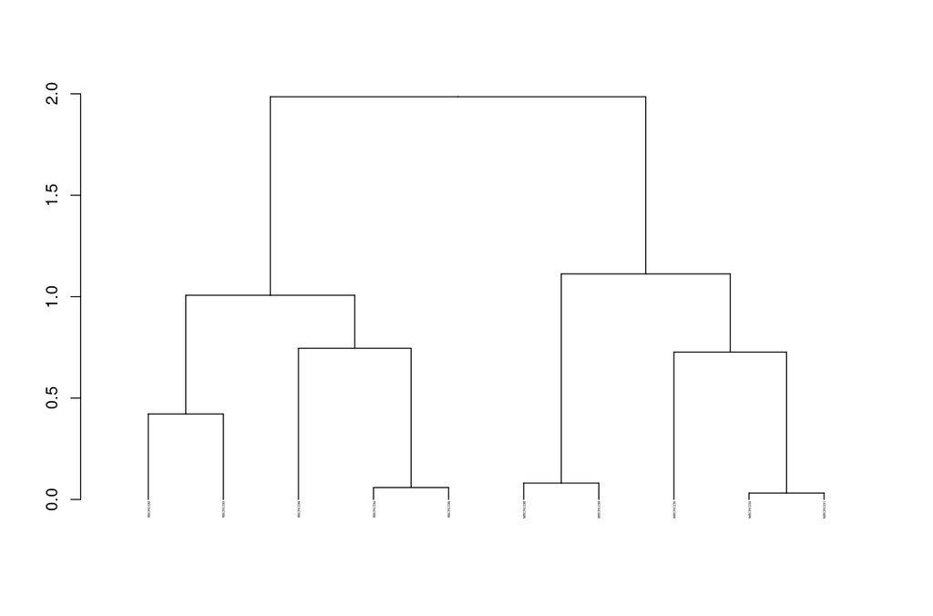

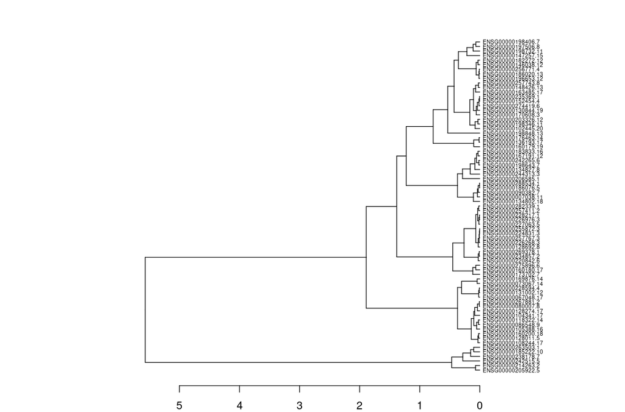

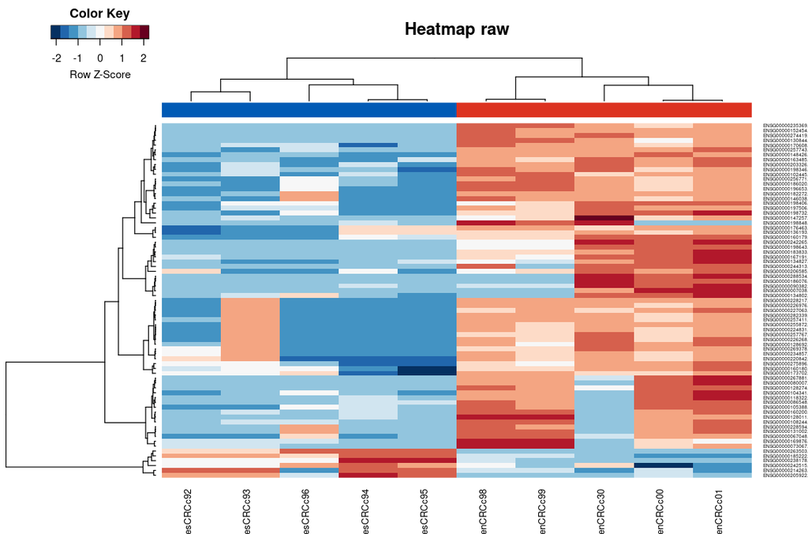

```r
# HEATMAP with the GENES that showed the highest variability between the 2 conditions:
par(oma=c(2,.5,.5,.5)) # all sides have X lines of space (bottom, left, top, right))
#
hmap(set = gseMXtopV,
     scale = 'row',
     tset = t(gseMXtopV),
     col = col,
     colsidecolors = colbars1,
     hcexRow = .5,
     hcexCol = 1,
     clustering = T,
     main = "Heatmap raw")
#
# The next HEATMAPs were also built with "hmap" with different data matrices:
### selecting just the first 100 genes NUT this does not give a sensible PLOT
# hmap(set = log2(gseMX_final[1:100,]+1),
#      scale = 'row',
#      tset = t(log2(gseMX_final[1:100,]+1)),
#      col = col,
#      colsidecolors = colbars1,
#      hcexRow = .5,
#      hcexCol = 1,
#      clustering = T,
#      main = "Heatmap raw")
### using ALL GENES
# hmap(set = log2(assay(gse_final)+1),
#      scale = 'row',
#      tset = t(log2(assay(gse_final)+1)),
#      col = col,
#      colsidecolors = colbars1,
#      hcexRow = .5,
#      hcexCol = 1,
#      clustering = T,
#      main = "Heatmap raw")
```

We check the total number of counts per sample, and more or less they are somewhat in the same range.

```r
apply(gseMX_final,2,sum)
#Using "assay"# apply(assay(gse_final),2,sum)
```

```
resCRCc92 resCRCc93 resCRCc94 resCRCc95 resCRCc96 senCRCc98 senCRCc99
 10650326  14064877  12059045   8086648  10934933  18287105  13448160
senCRCc00 senCRCc01 senCRCc30
  8804101  18974802  14987230
```

The data is not so bad, but we should try to normalize it to make it more comparable. We will perform quantile normalization.

### Install preprocessCore

```r
pacman::p_load("preprocessCore")
set.seed(261)
normalized_reads <- normalize.quantiles(gseMX_final)
colnames(normalized_reads) <- colnames(gseMX_final)
rownames(normalized_reads) <- rownames(gseMX_final)
apply(normalized_reads,2,sum)
#ALSO#
#Using "assay"# normalized_reads <- normalize.quantiles(assay(gse_final))
#Using "assay"# colnames(normalized_reads) <- colnames(assay(gse_final))
#Using "assay"# rownames(normalized_reads) <- rownames(assay(gse_final))
```

```
resCRCc92 resCRCc93 resCRCc94 resCRCc95 resCRCc96 senCRCc98 senCRCc99
 13029594  13029665  13029450  13029359  13029594  13029664  13029690
senCRCc00 senCRCc01 senCRCc30
 13029717  13029725  13029596
```

And we plot the DISTRIBUTIONS (boxplots) of the data to check if the normalization has been done.

[figure not shown]

```r
par(oma=c(3,.5,.5,.5)) # all sides have 3 lines of space (bottom, left, top, right))
boxplot(log2(normalized_reads+1), las = 2, col = c(rep("#DC3220",5), rep("#005AB5",5)))
```

And we plot also the DENSITIES (density plots) and a PAIR COMPARISON (scatter plot) of the data after the normalization.

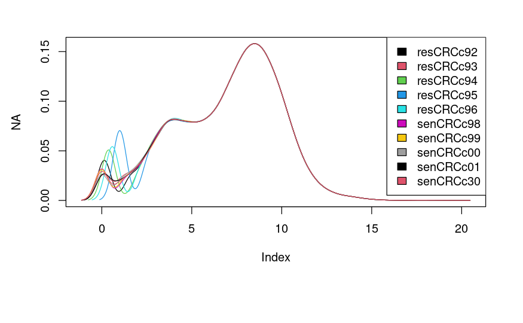

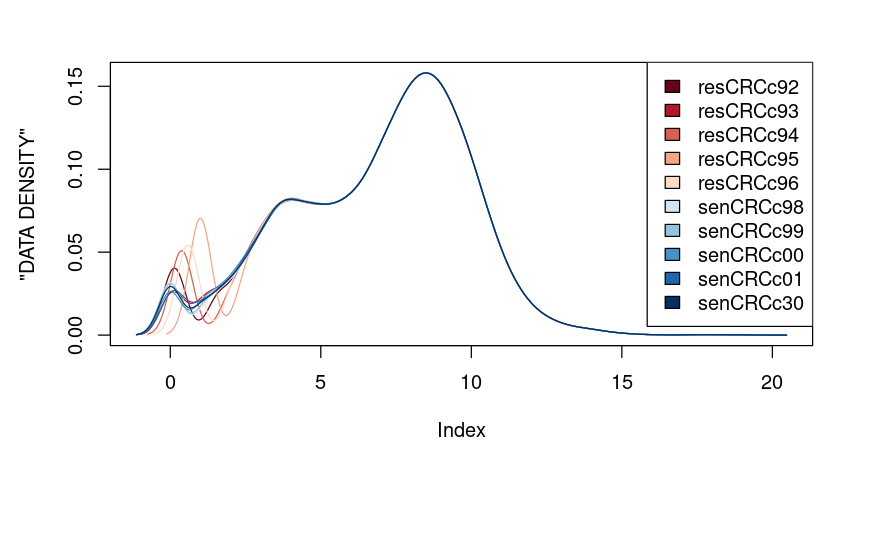

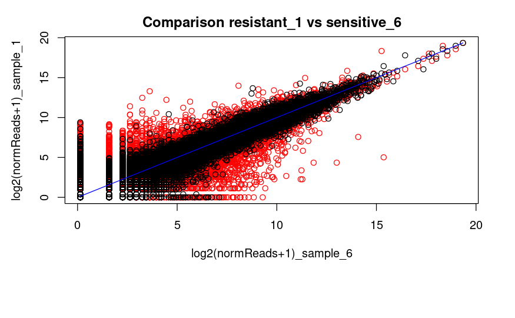

```r
# density plots
par(oma=c(3,.5,.5,.5)) # all sides have 3 lines of space (bottom, left, top, right))
dens <- apply(log2(normalized_reads+1), 2, density)
#
plot("DATA DENSITY 1", xlim=range(sapply(dens, "[", "x")), ylim=range(sapply(dens, "[", "y")))
mapply(lines, dens, col=1:length(dens))
legend("topright", legend=names(dens), fill=1:length(dens))
#
library("RColorBrewer")
display.brewer.pal(n = 10, name = 'RdBu')
###  col=brewer.pal(n = 10, name = "RdBu")
#
plot("DATA DENSITY 2", xlim=range(sapply(dens, "[", "x")), ylim=range(sapply(dens, "[", "y")))
mapply(lines, dens, col=brewer.pal(n = 10, name = "RdBu"))
legend("topright", legend=names(dens), fill=brewer.pal(n = 10, name = "RdBu"))

# scatter plot
par(oma=c(3,0.5,0.5,0.5))
par(mar=c(5,4,2,2) +0.1)
plot(log2(normalized_reads+1)[,1] , log2(normalized_reads+1)[,6] , main="Comparison resistant_1 vs sensitive_6",
  xlab="log2(normReads+1)_sample_6", ylab="log2(normReads+1)_sample_1" , col="red")
points(log2(normalized_reads+1)[,1] , log2(normalized_reads+1)[,2] , col="black")
lines(log2(normalized_reads+1)[,1] , log2(normalized_reads+1)[,1] , col="blue")

# MA plot
# An MA-plot could also be represented, see: https://en.wikipedia.org/wiki/MA_plot
# Plots the M = Log2-FoldChange(Ratio) versus the A = Log2-Concentration(AverageSignal), M versus A
# scatter plot of log2 fold changes (M, on y-axis) versus the average expression signal (A, on x-axis)
# M = log2(x/y) and A = (log2(x)+log2(y))/2 = log2(xy)*1/2
# See: https://www.sciencedirect.com/topics/biochemistry-genetics-and-molecular-biology/ma-plot
# See: https://rpkgs.datanovia.com/ggpubr/reference/ggmaplot.html
```

We can also plot a heatmap to check how is it

```r
# As above it is better to select GENES with highest variability between the 2 conditions: res 1:5 ; sen 6:10
summary(rowSds(log2(normalized_reads+1)))
```

```
   Min. 1st Qu.  Median    Mean 3rd Qu.    Max.
 0.1023  0.5545  0.8175  1.0608  1.3417  5.2158
```

```r
gseMXnm <- log2(normalized_reads[,]+1)
dim(gseMXnm)
```

```
[1] 16949    10
```

```r
table( abs(rowMeans(gseMXnm[,1:5])-rowMeans(gseMXnm[,6:10])) > 5.0)
```

```
FALSE  TRUE
16904    45
```

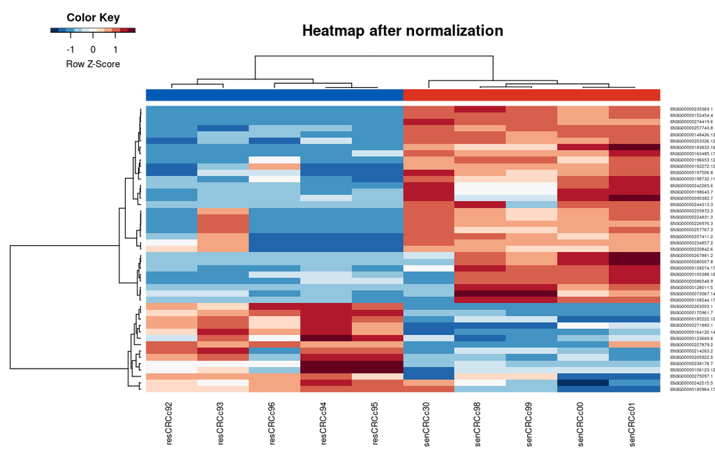

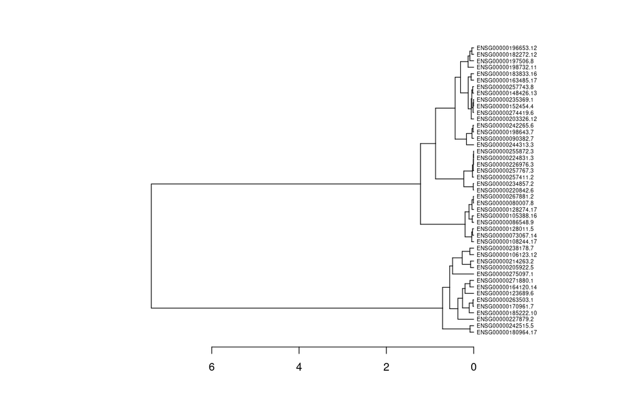

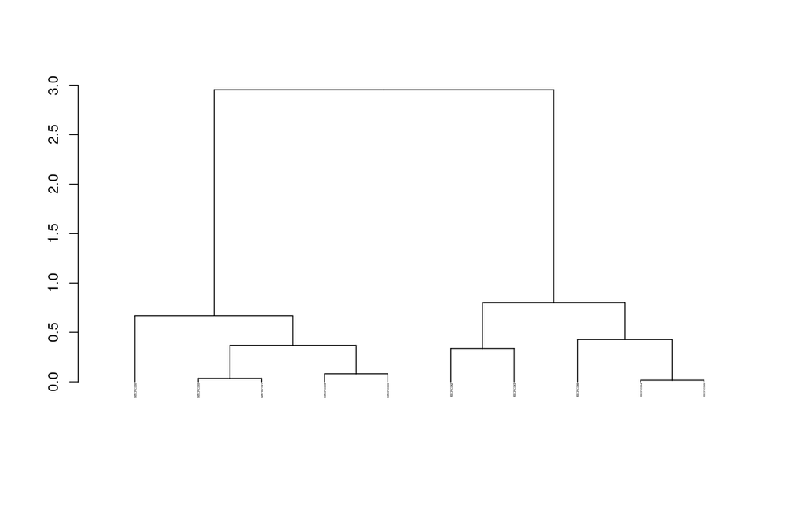

```r
gseMXtopVn <- gseMXlg[abs(rowMeans(gseMXnm[,1:5])-rowMeans(gseMXnm[,6:10]))>5.0,]

par(oma=c(3,.5,.5,.5)) # all sides have 3 lines of space (bottom, left, top, right))
#
hmap(set = gseMXtopVn,
     scale = 'row',
     tset = t(gseMXtopVn),
     col = col,
     colsidecolors = colbars1,
     hcexRow = .5,
     hcexCol = 1,
     clustering = T,
     main = "Heatmap after normalization")
#
#ALSO# using ALL GENES (i.e. the whole gene set of 16904g)
# hmap(set = normalized_reads,
#      scale = 'row',
#      tset = t(normalized_reads),
#      col = col,
#      colsidecolors = colbars1,
#      hcexRow = .5,
#      hcexCol = 1,
#      clustering = T,
#      main = "Heatmap after normalization")
```

After this we can perform differential expression. The first step is to create a DGEList object.

```r
pacman::p_load("edgeR")
# load("datafiles4de.Rdata")
d0 <- DGEList(normalized_reads)
d0
```

```
An object of class "DGEList"
$counts
                   resCRCc92 resCRCc93 resCRCc94 resCRCc95 resCRCc96
ENSG00000000003.15    357.80    274.40     548.9    288.35    578.45
ENSG00000000419.14    530.60    499.75     509.0    372.85    361.90
ENSG00000000457.14    224.80    219.90     123.2     78.00    152.30
ENSG00000000460.17    264.40    101.80     215.3    312.20    197.20
ENSG00000001036.14    640.65    588.80     929.9    869.95    891.40
                   senCRCc98 senCRCc99 senCRCc00 senCRCc01 senCRCc30
ENSG00000000003.15    638.75     781.5     304.5     378.2     517.8
ENSG00000000419.14   1168.40    1009.1     640.7     714.8     475.5
ENSG00000000457.14    105.00     118.3      98.4     144.6     675.5
ENSG00000000460.17    221.90     170.3     107.7     121.0     183.4
ENSG00000001036.14    468.50     275.7     600.4    1102.4    1424.8
16944 more rows ...

$samples
         group lib.size norm.factors
resCRCc92     1 13029594            1
resCRCc93     1 13029665            1
resCRCc94     1 13029450            1
resCRCc95     1 13029359            1
resCRCc96     1 13029594            1
senCRCc98     1 13029664            1
senCRCc99     1 13029690            1
senCRCc00     1 13029717            1
senCRCc01     1 13029725            1
senCRCc30     1 13029596            1
```

### Install edgeR

First we calculate normalization factors. calcNormFactors doesn’t normalize the data, it just calculates normalization factors for use downstream.

```r
d0 <- calcNormFactors(d0)
d0
```

```
An object of class "DGEList"
$counts
                  resCRCc92 resCRCc93 resCRCc94 resCRCc95 resCRCc96 senCRCc98 senCRCc99 senCRCc00 senCRCc01 senCRCc30
ENSG00000000003.15    357.80    274.40     548.9    288.35    578.45    638.75     781.5     304.5     378.2     517.8
ENSG00000000419.14    530.60    499.75     509.0    372.85    361.90   1168.40    1009.1     640.7     714.8     475.5
ENSG00000000457.14    224.80    219.90     123.2     78.00    152.30    105.00     118.3      98.4     144.6     675.5
ENSG00000000460.17    264.40    101.80     215.3    312.20    197.20    221.90     170.3     107.7     121.0     183.4
ENSG00000001036.14    640.65    588.80     929.9    869.95    891.40    468.50     275.7     600.4    1102.4    1424.8
 16944 more rows ...

 $samples
           group lib.size norm.factors
resCRCc92     1 13029594    1.0212406
resCRCc93     1 13029665    1.0227475
resCRCc94     1 13029450    0.9477376
resCRCc95     1 13029359    0.9684974
resCRCc96     1 13029594    1.0070091
senCRCc98     1 13029664    1.0605930
senCRCc99     1 13029690    1.0490547
senCRCc00     1 13029717    0.9245159
senCRCc01     1 13029725    0.9677416
senCRCc30     1 13029596    1.0405498
```

Next we will filter low expressed genes. “Low-expressed” is subjective and depends on the dataset.

```r
cutoff <- 1
drop <- which(apply(cpm(d0), 1, max) < cutoff)
d <- d0[-drop,]
dim(d) # number of genes left
```

```
[1] 16841    10
```

We save our resistance data into a new variable

```r
group <- SummarizedExperiment::colData(gse_final)[,"cetuximab_resistance"]
group <- as.factor(group)
group
```

```
 [1] resistant resistant resistant resistant resistant sensitive sensitive
 [8] sensitive sensitive sensitive
Levels: resistant sensitive
```

Next we can check Multidimensional scaling (MDS) plot

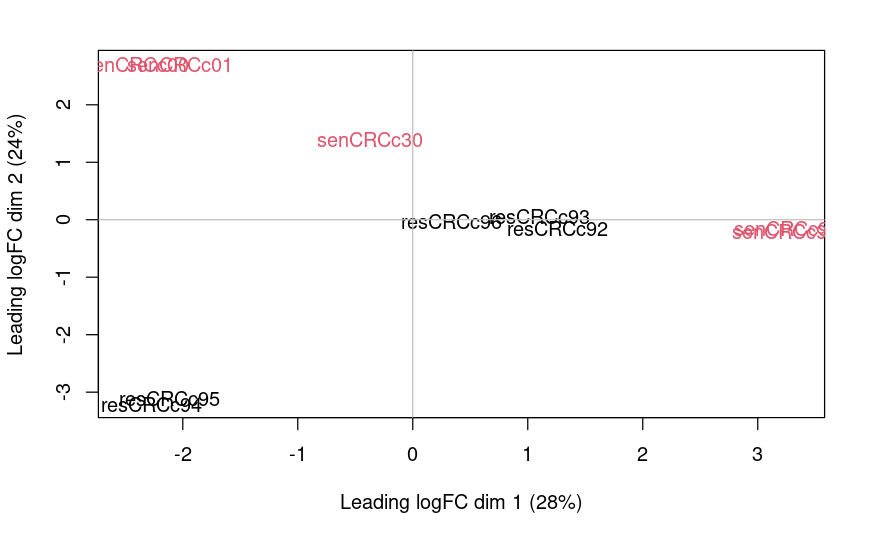

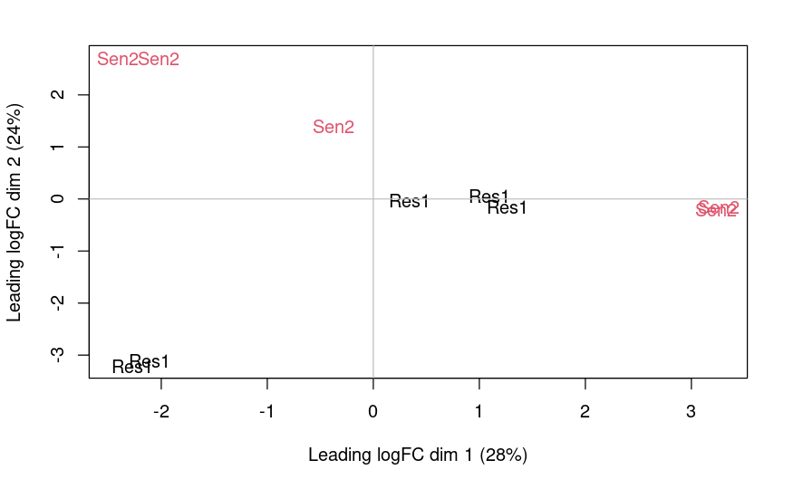

```r
plotMDS(d, col = as.numeric(group), labels=colnames(d))
abline(h=0,col="grey")
abline(v=0,col="grey")
#
plotMDS(d, col = as.numeric(group) , labels= c(rep("Res1",5), rep("Sen2",5)) )
abline(h=0,col="grey")
abline(v=0,col="grey")
```

Next we will perform the voom transformation and the calculation of variance weigths. First, we specify the model to be fitted. We do this before using voom since voom uses variances of the model residuals (observed - fitted)

```r
mm <- model.matrix(~0 + group)
mm
```

```
   groupresistant groupsensitive
1               1              0
2               1              0
3               1              0
4               1              0
5               1              0
6               0              1
7               0              1
8               0              1
9               0              1
10              0              1
attr(,"assign")
[1] 1 1
attr(,"contrasts")
attr(,"contrasts")$group
[1] "contr.treatment"
```

The above specifies a model where each coefficient corresponds to a group mean.

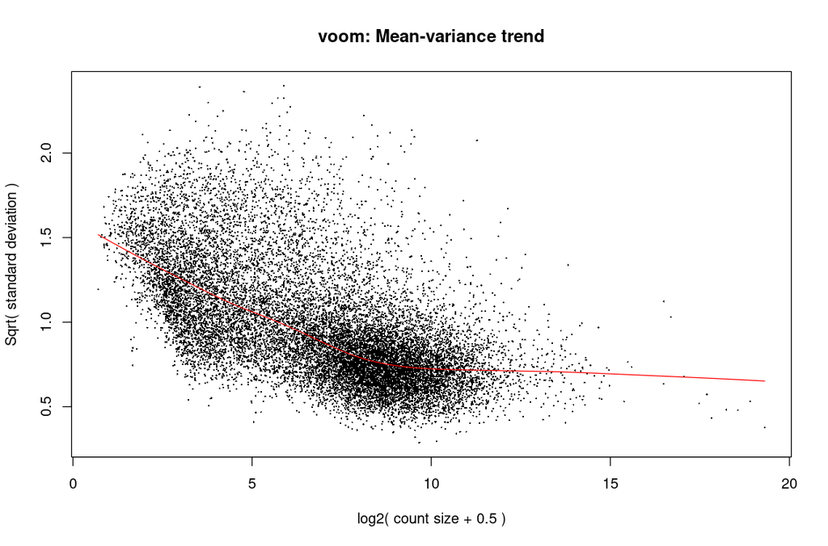

```r
y <- voom(d, mm, plot = T)
# str(d)
# Formal class 'DGEList' [package "edgeR"] with 1 slot
# ...
# str(y)
# Formal class 'EList' [package "limma"] with 1 slot
# ...
```

What is voom doing?:

Counts are transformed to log2 counts per million reads (CPM), where “per million reads” is defined based on the normalization factors we calculated earlier. A linear model is fitted to the log2 CPM for each gene, and the residuals are calculated. A smoothed curve is fitted to the sqrt(residual standard deviation) by average expression (see red line in plot above). The smoothed curve is used to obtain weights for each gene and sample that are passed into limma along with the log2 CPMs.

Transform RNA-Seq Data Ready for Linear Modelling - voom(limma) Description: Transform count data to log2-counts per million (logCPM), estimate the mean-variance relationship and use this to compute appropriate observation-level weights. The data are then ready for linear modelling. Usage: voom(counts, design = NULL, lib.size = NULL, normalize.method = “none”, block=NULL, correlation=NULL, weights=NULL, span=0.5, plot=FALSE, save.plot=FALSE)

More details at https://genomebiology.biomedcentral.com/articles/10.1186/gb-2014-15-2-r29

The above is a “good” voom plot. If your voom plot looks like the below, you might want to filter more:

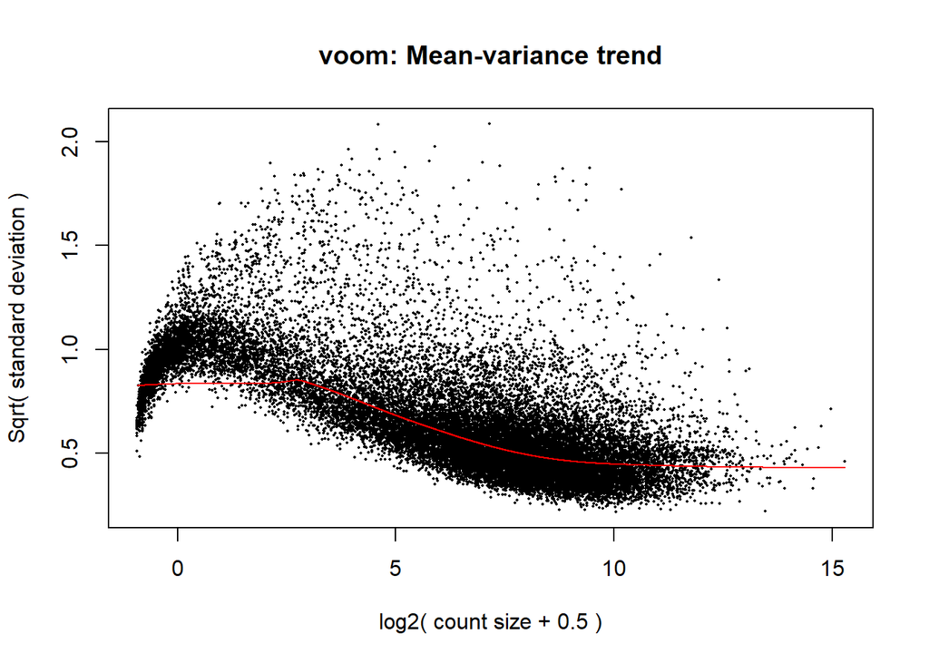

The next step is fitting linear models in limma

```r
fit <- lmFit(y, mm)
head(coef(fit))
```

```
                   groupresistant groupsensitive
ENSG00000000003.15       4.912634       5.244523
ENSG00000000419.14       5.117968       5.861404
ENSG00000000457.14       3.534570       3.658691
ENSG00000000460.17       3.980055       3.579782
ENSG00000001036.14       5.896456       5.643019
ENSG00000001084.13       5.522446       5.558454
```

Specify which groups to compare, in this case we only have two groups:

```r
contr <- makeContrasts(groupresistant - groupsensitive, levels = colnames(coef(fit)))
contr
```

```
                Contrasts
Levels           groupresistant - groupsensitive
  groupresistant                               1
  groupsensitive                              -1
```

Estimate contrast for each gene

```r
tmp <- contrasts.fit(fit, contr)
```

Empirical Bayes smoothing of standard errors (shrinks standard errors that are much larger or smaller than those from other genes towards the average standard error) (see https://www.degruyter.com/doi/10.2202/1544-6115.1027)

```r
tmp <- eBayes(tmp)
```

### Calculate genes differential expression

What genes are most differentially expressed?

```r
top.table <- topTable(tmp, sort.by = "P", n = Inf)
head(top.table, 12)
```

```
                      logFC    AveExpr          t      P.Value   adj.P.Val        B
ENSG00000203326.12 -5.326225  1.3613344 -10.420240 3.353797e-07 0.004806267 5.239035
ENSG00000152454.4  -6.981008 -0.5013794  -9.902006 5.707817e-07 0.004806267 3.769613
ENSG00000101350.8  -1.912930  5.4157087  -7.967949 5.158249e-06 0.022663509 4.522696
ENSG00000126016.17 -3.104801  1.8910262  -7.616063 8.028315e-06 0.022663509 3.662323
ENSG00000167969.13  1.421662  6.1516331   7.454415 9.884862e-06 0.022663509 3.879928
ENSG00000284820.1   2.612561  3.2486898   7.453225 9.900133e-06 0.022663509 3.778867
ENSG00000120708.17 -3.215962  6.4754734  -7.409695 1.047618e-05 0.022663509 3.826789
ENSG00000257743.8  -6.661798  1.3545749  -7.315782 1.184490e-05 0.022663509 2.751184
ENSG00000235369.1  -5.716545 -1.1380723  -7.298839 1.211161e-05 0.022663509 2.100126
ENSG00000164120.14  5.880574 -0.6102387   7.180184 1.416943e-05 0.023599080 2.066891
ENSG00000148426.13 -7.908004  0.5007634  -7.074403 1.632093e-05 0.023599080 2.121491
ENSG00000274419.6  -6.480710 -0.7546451  -7.048084 1.690884e-05 0.023599080 1.978881
```

```
logFC: log2 fold change of resistant/sensitive
AveExpr: Average expression across all samples, in log2 CPM
t: logFC divided by its standard error
P.Value: Raw p-value (based on t) from test that logFC differs from 0
adj.P.Val: Benjamini-Hochberg false discovery rate adjusted p-value
B: log-odds that gene is DE (arguably less useful than the other columns)
```

ENSG00000203326 gene will be more expressed in sensitive samples because the logFC is negative. ENSG00000284820 gene will be more expressed in resistant samples.

How many DE genes are there?

```r
length(which(top.table$adj.P.Val < 0.05))
```

```
[1] 74
```

```r
# We need to have installed & charged in R this packages
pacman::p_load(ggplot2, tidyverse, ggpubr)
pacman::p_load(reshape2)
#
rownames(normalized_reads) <- gsub("\\..*", "", rownames(normalized_reads))
head(normalized_reads, 5)
```

```
                resCRCc92 resCRCc93 resCRCc94 resCRCc95 resCRCc96
ENSG00000000003    357.80    274.40     548.9    288.35    578.45
ENSG00000000419    530.60    499.75     509.0    372.85    361.90
ENSG00000000457    224.80    219.90     123.2     78.00    152.30
ENSG00000000460    264.40    101.80     215.3    312.20    197.20
ENSG00000001036    640.65    588.80     929.9    869.95    891.40
                senCRCc98 senCRCc99 senCRCc00 senCRCc01 senCRCc30
ENSG00000000003    638.75     781.5     304.5     378.2     517.8
ENSG00000000419   1168.40    1009.1     640.7     714.8     475.5
ENSG00000000457    105.00     118.3      98.4     144.6     675.5
ENSG00000000460    221.90     170.3     107.7     121.0     183.4
ENSG00000001036    468.50     275.7     600.4    1102.4    1424.8
```

```r
data_to_plot <- normalized_reads[rownames(normalized_reads) %in% c("ENSG00000152454", "ENSG00000164120"),] %>% reshape2::melt()
data_to_plot$group <- c(rep("resistant", 10), rep("sensitive", 10))
colnames(data_to_plot) <- c("gene", "sample", "value", "group")
data_to_plot
```

```
              gene    sample  value     group
1  ENSG00000152454 resCRCc92   0.10 resistant
2  ENSG00000164120 resCRCc92  31.40 resistant
3  ENSG00000152454 resCRCc93   0.00 resistant
4  ENSG00000164120 resCRCc93  71.40 resistant
5  ENSG00000152454 resCRCc94   0.30 resistant
6  ENSG00000164120 resCRCc94 137.20 resistant
7  ENSG00000152454 resCRCc95   1.00 resistant
8  ENSG00000164120 resCRCc95  63.90 resistant
9  ENSG00000152454 resCRCc96   0.50 resistant
10 ENSG00000164120 resCRCc96  57.70 resistant
11 ENSG00000152454 senCRCc98 187.70 sensitive
12 ENSG00000164120 senCRCc98   1.20 sensitive
13 ENSG00000152454 senCRCc99 112.40 sensitive
14 ENSG00000164120 senCRCc99   1.20 sensitive
15 ENSG00000152454 senCRCc00  94.55 sensitive
16 ENSG00000164120 senCRCc00   1.00 sensitive
17 ENSG00000152454 senCRCc01  68.00 sensitive
18 ENSG00000164120 senCRCc01   0.30 sensitive
19 ENSG00000152454 senCRCc30  87.15 sensitive
20 ENSG00000164120 senCRCc30   0.00 sensitive
```

[figure not shown]

```r
# Plot 2 top genes: ENSG00000152454 = ZNF256 and ENSG00000164120 = HPGD
ggplot() +
  geom_tile(data = data_to_plot, aes(x = sample, y = -1, height = .5, fill = group)) +
  scale_fill_manual(values = c("black", "grey")) +
  geom_line(data = data_to_plot %>% filter(gene %in% "ENSG00000152454"),
            aes(x = sample, y = log2(value+1), group = group, color = gene)) +
  geom_line(data = data_to_plot %>% filter(gene %in% "ENSG00000164120"),
            aes(x = sample, y = log2(value+1), group = group, color = gene)) +

  geom_point(data = data_to_plot, aes(x = sample, y = log2(value+1), group = group, color = gene)) +
  # Labels added
  xlab("") +
  ylab("Normalized Reads log2(expr+1)") +
  # Adding the title
  labs(title = "Signal of 2 GENES diff. express. in Resistant v Sensitive") +
  # Setting the theme to minimal so it can be customized to the desired style
  theme_minimal(base_size = 9) +
  theme(text             = element_text(size = 10),
        panel.background = element_rect(fill = 'white'),
        panel.grid.major = element_line(colour = "grey", size = .2),
        panel.grid.minor = element_line(colour = "grey", size = .2),
        legend.position  = 'bottom',
        legend.text      = element_text(size = 8),
        legend.title     = element_text(size = 10),
        plot.title       = element_text(size = 14, face = "bold"),
        plot.subtitle    = element_text(size = 12, face = "italic", color = "black"),
        axis.text.x      = element_text(angle = 90),
        axis.title.y     = element_text(size = 12, margin = margin(t = 0, r = 20, b = 0, l = 0)),
        axis.title.x     = element_text(size = 12, margin = margin(t = 20, r = 0, b = 0, l = 0)))
```

Write top.table to a file

```r
top.table$Gene <- rownames(top.table)
top.table <- top.table[,c("Gene", names(top.table)[1:6])]
write.table(top.table, file = "output/resistant_v_sensitive_gene_expr.txt", row.names = F, sep = "\t", quote = F)
```

Write top.table to a file but now adding GENEs INFORMATION

```r
# Adding gene information with biomart
pacman::p_load(biomaRt)
mart.hs <- useMart("ensembl", "hsapiens_gene_ensembl", host = "https://www.ensembl.org")
View(listAttributes(mart.hs))

# The query we are going to search are the ENSG without the .xx
query1 <- top.table$Gene
query1 <- gsub("\\..*", "", top.table$Gene)
#
query_res <- getBM(attributes = c('ensembl_gene_id', 'hgnc_symbol', 'description'),
                   filters = 'ensembl_gene_id', values = query1, mart = mart.hs)
#
top.table$ensg         <- query1
top.table$symbol       <- query_res$hgnc_symbol[match(top.table$ensg, query_res$ensembl_gene_id)]
top.table$descripction <- query_res$description[match(top.table$ensg, query_res$ensembl_gene_id)]

top.tableF <- top.table[,c(8,9,2:7,10)]
rownames(top.tableF) <- top.tableF$ensg
#
write.table(top.tableF, file = "output/resistant_v_sensitive_gene_exprINFO.txt", row.names = F, sep = "\t", quote = F)
head(top.tableF, 7)
```

```
                                 Gene     logFC    AveExpr          t      P.Value   adj.P.Val        B            ensg symbol
ENSG00000203326.12 ENSG00000203326.12 -5.326225  1.3613344 -10.420240 3.353797e-07 0.004806267 5.239035 ENSG00000203326 ZNF525
ENSG00000152454.4   ENSG00000152454.4 -6.981008 -0.5013794  -9.902006 5.707817e-07 0.004806267 3.769613 ENSG00000152454 ZNF256
ENSG00000101350.8   ENSG00000101350.8 -1.912930  5.4157087  -7.967949 5.158249e-06 0.022663509 4.522696 ENSG00000101350  KIF3B
ENSG00000126016.17 ENSG00000126016.17 -3.104801  1.8910262  -7.616063 8.028315e-06 0.022663509 3.662323 ENSG00000126016   AMOT
ENSG00000167969.13 ENSG00000167969.13  1.421662  6.1516331   7.454415 9.884862e-06 0.022663509 3.879928 ENSG00000167969   ECI1
ENSG00000284820.1   ENSG00000284820.1  2.612561  3.2486898   7.453225 9.900133e-06 0.022663509 3.778867 ENSG00000284820
ENSG00000120708.17 ENSG00000120708.17 -3.215962  6.4754734  -7.409695 1.047618e-05 0.022663509 3.826789 ENSG00000120708  TGFBI
                                                                                  descripction
ENSG00000203326.12                 zinc finger protein 525 [Source:HGNC Symbol;Acc:HGNC:29423]
ENSG00000152454.4                  zinc finger protein 256 [Source:HGNC Symbol;Acc:HGNC:13049]
ENSG00000101350.8                  kinesin family member 3B [Source:HGNC Symbol;Acc:HGNC:6320]
ENSG00000126016.17                              angiomotin [Source:HGNC Symbol;Acc:HGNC:17810]
ENSG00000167969.13              enoyl-CoA delta isomerase 1 [Source:HGNC Symbol;Acc:HGNC:2703]
ENSG00000284820.1                                                                novel protein
ENSG00000120708.17 transforming growth factor beta induced [Source:HGNC Symbol;Acc:HGNC:11771]
```

Plot a volcano plot of the results

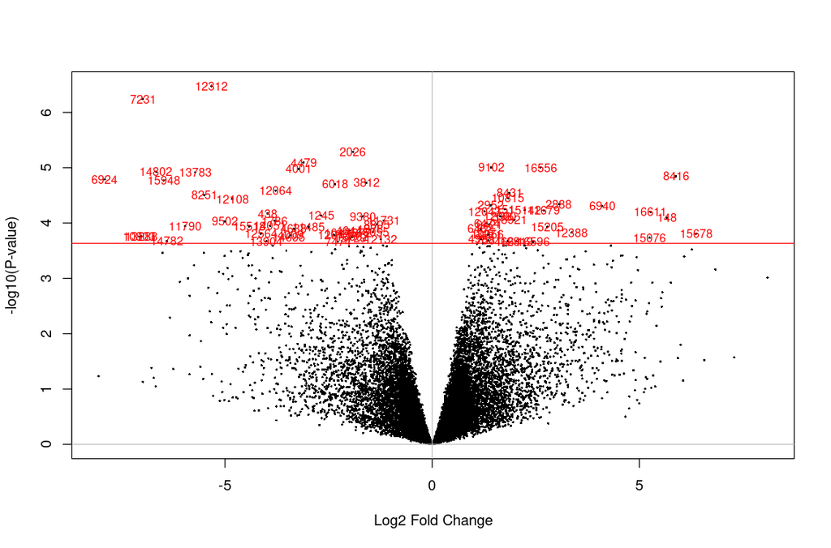

```r
# Use tmp[12312,] to see the values of the genes plotted
volcanoplot(tmp,
            coef = 1,
            style = "p-value",
            highlight = 74,  # We hightlight the 74 significant genes
            names = seq(1, nrow(tmp$coefficients)),
            hl.col = "red",
            xlab = "Log2 Fold Change",
            ylab = NULL,
            pch = 16,
            cex = 0.35)
#
abline(h=0,col="grey")
abline(v=0,col="grey")
###  -log10(0.05)
# [1] 1.30103
###  abline(h=1.30103,col="red")
###  -log10(0.000233)
# [1] 3.632644
abline(h=3.632644,col="red")
```

And a heatmap of the significant genes

```r
significant_genes <- top.table$Gene[top.table$adj.P.Val < 0.05]
significant_genes<- gsub("\\..*", "", significant_genes)

signifcant_normalized_reads <- normalized_reads[rownames(normalized_reads) %in% significant_genes,]
dim(signifcant_normalized_reads)
```

```
[1] 74 10
```

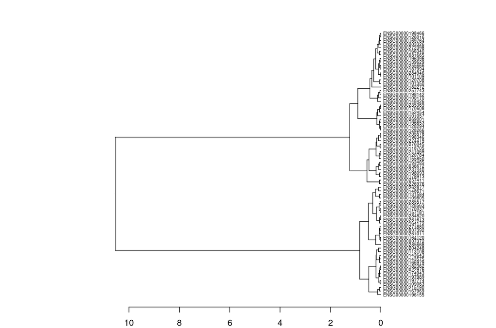

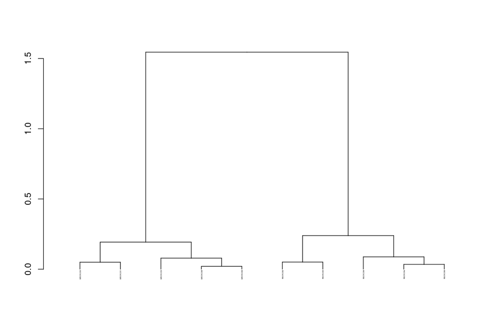

[figure not shown]

```r
# source('hmap.R')
# pacman::p_load(RColorBrewer, gplots, dendextend)
# col <- brewer.pal(11,"RdBu")
# col <- rev(col)
# colbars1 <- c(rep("#005AB5" ,5), rep("#DC3220",5))
#
hmap(set = signifcant_normalized_reads,
     scale = 'row',
     tset = t(signifcant_normalized_reads),
     col = col,
     colsidecolors = colbars1,
     hcexRow = .5,
     hcexCol = .8,
     clustering = T,
     main = "Heatmap 74 DEgenes - Resistant_v_Sensitive")
```